# Dealer Concentration in Ohio

This notebook describes concentration among new-car dealerships in Ohio.

One question to have in mind during all of this: *What is HHI actually telling us?* Espeically in a highly differentiated product market with strong preferences for types of products.

## Top Dealer Groups

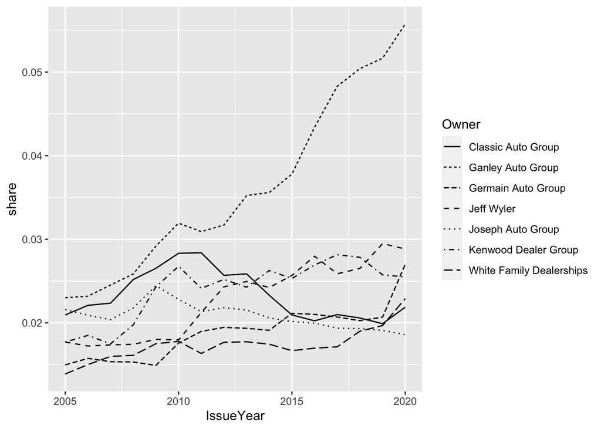

## Concentration

#### HHI at the state level

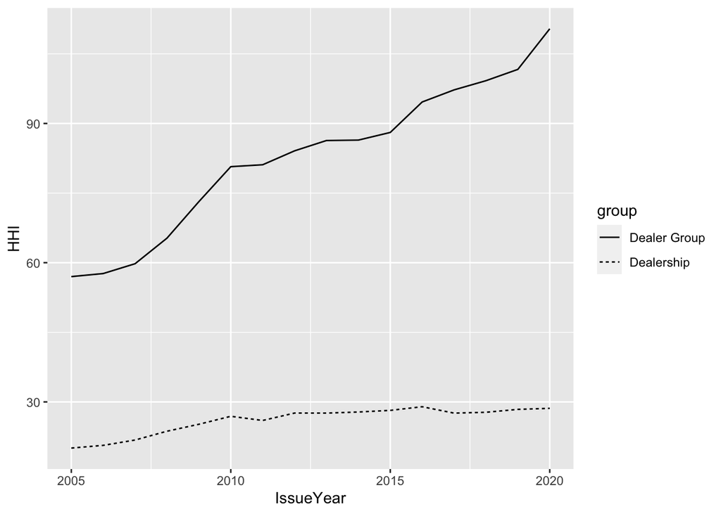

#### HHI at the DMA level

The next figures look at HHI, where the market is defined as a DMA. Note that Cincinnati and Toledo have dealers in Kentucky/Michigan, so those numbers are less accurate. Concentration is substantially higher when defined at the Dealer Group level. [Note: the axes are different!!]

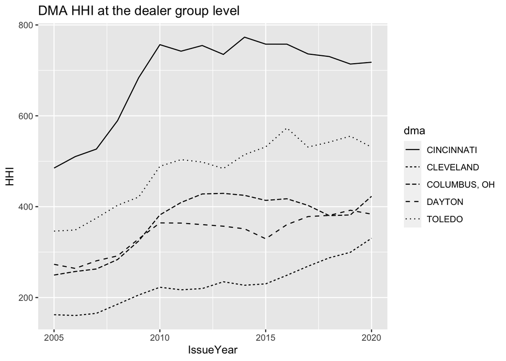

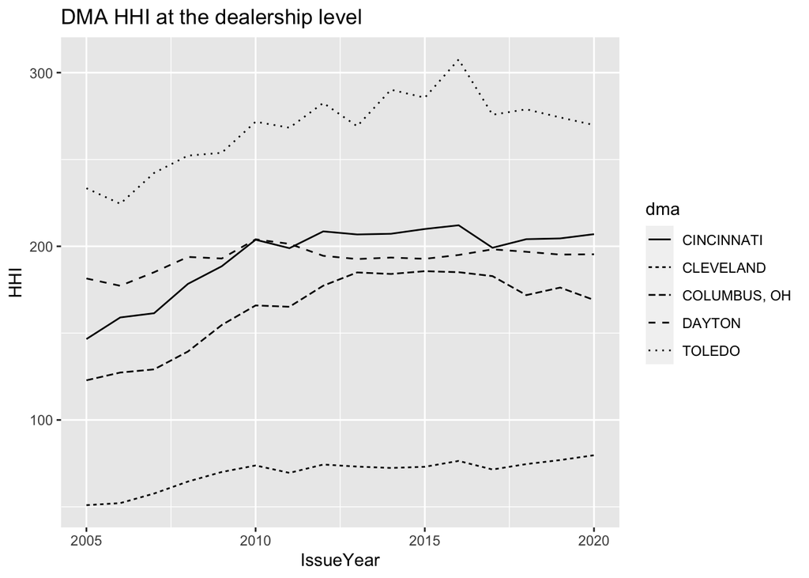

#### HHI at the zipcode level

Next, define a market as a buyer’s zipcode. That is, if 100 buyers in a zipcode purchase a car in a given year, HHI describes the concentration of dealer-owners for those 100 buyers.

First, let’s look at the distribution of sales across buyer zipcodes in 2019.

```
## # A tibble: 5 × 2
##   Sales Percentile
##   <dbl>      <dbl>
## 1    4        0.1
## 2   23        0.25
## 3  112        0.5
## 4  476        0.75
## 5 1261.       0.9
```

Next, let’s look at HHI at the dealer-group and dealership level, in 2109. These are a bit hard to compare, but the Dealer-Group histogram (mean=1020) is farther to the right of the Dealership histogram (mean=662.

```
## # A tibble: 1 × 2
##   IssueYear   hhi
##       <dbl> <dbl>
## 1      2019 1020.
```

```
## # A tibble: 1 × 2
##   IssueYear   hhi
##       <dbl> <dbl>
## 1      2019  662.
```

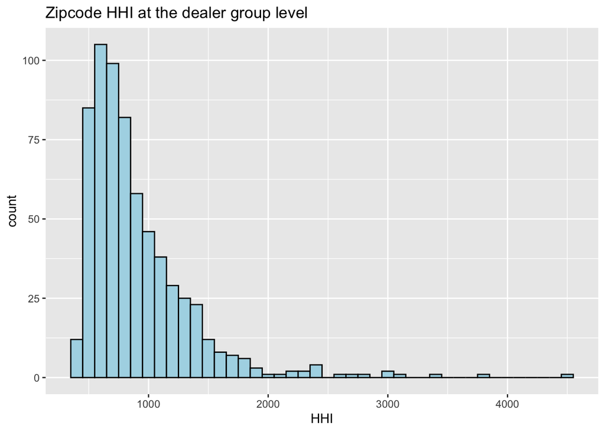

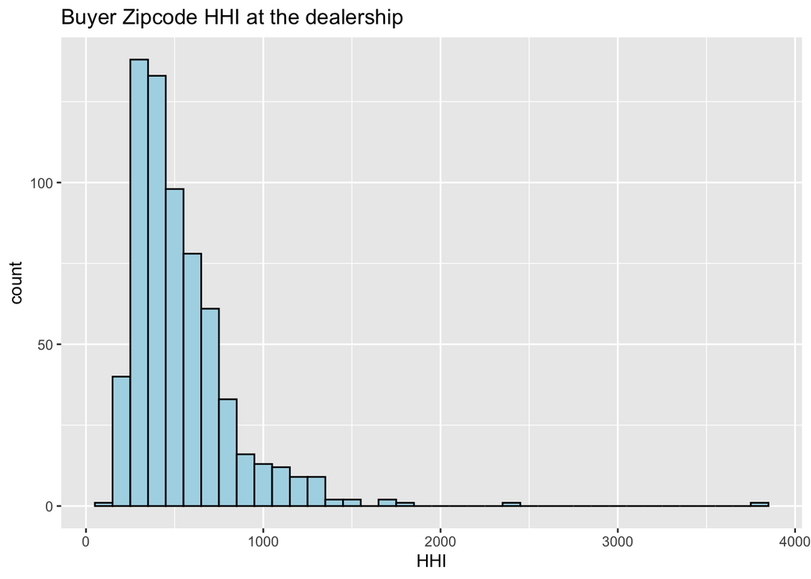

The difference between 1020 and 662 is big, especially in light of Nocke and Whinston. But that is not just one merger. What is the policy recommendataion? What happens if you block all mergers?? Seems not right.